# Stat 579 - Homework #6

Urminder Singh

10/11/2018

## Another look at the Behavioral Risk Factor Surveillance System

We are, again, using the data from the Behavioral Risk Factor Surveillance System (BRFSS). Just as a reminder, the BRFSS surveys six individual-level behavioral health risk factors associated with the leading causes of premature mortality and morbidity among adults: 1) cigarette smoking, 2) alcohol use, 3) physical activity, 4) diet, 5) hypertension, and 6) safety belt use.

A subset of the data concentrating on Iowa with records for 2012 is given at http://www.hofroe.net/data/iowa-brfss-2012.csv

The following code reads the data into your R session:

```r
library(tidyverse)
```

```r
library("ggplot2", lib.loc="~/R/win-library/3.4")
```

A codebook describing the survey and a listing of all variables is available at http://www.cdc.gov/brfss/annual_data/2012/pdf/CODEBOOK12_LLCP.pdf.

For each of the questions, show the code necessary to retrieve the answer. Make sure to also write the answer to the question in a sentence.

1. Download the RMarkdown file with these homework instructions to use as a template for your work. Make sure to replace “Your Name” in the YAML with your name.
2. Load the dataset into your session and store it in the object `iowa`.

```r
iowa <- read.csv("iowa-brfss-2012.csv")
```

3. Check the codebook for an explanation of the variable `DRNKDRI2`. Do a frequency breakdown of the variable `DRNKDRI2` (visually or numerically). Comment. Introduce a variable `drinkdrive` into the `iowa` data set that encodes 88 as 0, and 77 and 99 as `NA`.  
   Hint: a combination of `mutate` and `ifelse` might be helpful.  
   Find the following summaries:
   1. What is the average number of times respondents admitted to driving under the influence in the past 30 days?
   2. On how many reports is this average based (exclude missing values)?
   3. Is there a difference in this average between the genders? Is that difference significant?

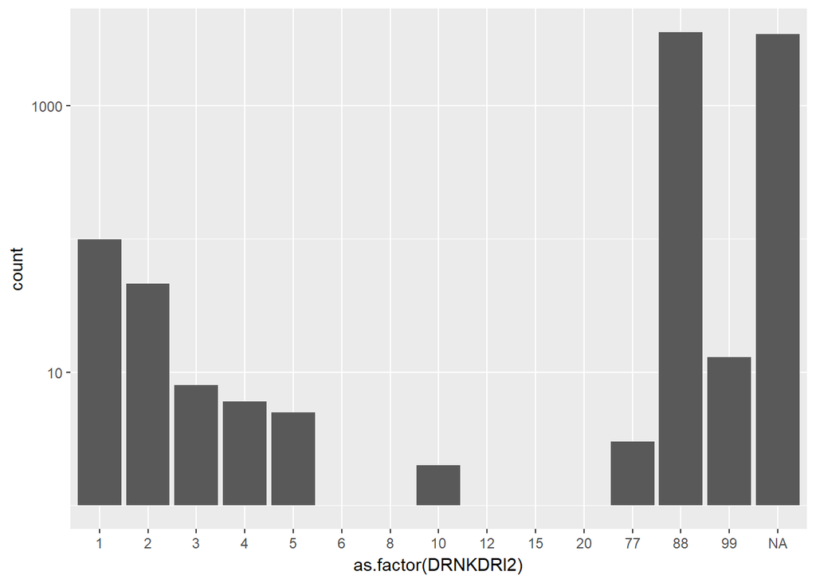

```r
ggplot(data=iowa,aes(x=as.factor(DRNKDRI2))) + geom_bar() + scale_y_log10()
```

```r
sort(table(iowa$DRNKDRI2,useNA = "ifany"))
```

```
##
##    6    8   12   15   20   10   77    5    4    3   99    2    1 <NA>   88
##    1    1    1    1    1    2    3    5    6    8   13   46   99 3442 3537
```

```r
#iowa<-iowa %>% mutate(drinkdrive = (DRNKDRI2 == 88 )*0)
iowa<-iowa %>% mutate(drinkdrive = ifelse(DRNKDRI2 == 88, 0, ifelse(DRNKDRI2 == 77 | DRNKDRI2 == 99, NA, DRNKDRI2)))
summary(iowa[which(!is.na(iowa$drinkdrive)),c('drinkdrive')])
```

```
##     Min.  1st Qu.   Median     Mean  3rd Qu.     Max.
##  0.00000  0.00000  0.00000  0.09304  0.00000 20.00000
```

```r
length(iowa[which(!is.na(iowa$drinkdrive)),c('drinkdrive')])
```

```
## [1] 3708
```

```r
#for male
males<-iowa[which(!is.na(iowa$drinkdrive) & iowa$SEX==1),c('drinkdrive')]
summary(males)
```

```
##    Min. 1st Qu.  Median    Mean 3rd Qu.    Max.
##  0.0000  0.0000  0.0000  0.1621  0.0000 20.0000
```

```r
length(males)
```

```
## [1] 1777
```

```r
#female
females<-iowa[which(!is.na(iowa$drinkdrive) & iowa$SEX==2),c('drinkdrive')]
summary(females)
```

```
##    Min. 1st Qu.  Median    Mean 3rd Qu.    Max.
## 0.00000 0.00000 0.00000 0.02952 0.00000 4.00000
```

```r
length(females)
```

```
## [1] 1931
```

```r
t.test(males,females)
```

```
##
##  Welch Two Sample t-test
##
## data:  males and females
## t = 5.9186, df = 1954.2, p-value = 3.825e-09
## alternative hypothesis: true difference in means is not equal to 0
## 95 percent confidence interval:
##  0.08863004 0.17647500
## sample estimates:
##  mean of x  mean of y
## 0.16207091 0.02951838
```

- average number of times respondents admitted to driving under the influence in the past 30 days: 0.0930421
- On how many reports is this average based (exclude missing values): 3708
- avg for male: 0.1620709
- avg for female: 0.0295184
- T-test gives very low p value thus we can say there is a difference between the male and female average.
4. Current smoking status is imputed in the variable `X_SMOKER3` (corresponds to variable `_SMOKER3` in the codebook). Make `X_SMOKER3` a factor. Relabel levels 1, 2, 3, 4 to `Current Smoker`, `Current Smoker`, `Former Smoker` and `Never Smoked` (yes, `Current Smoker` is repeated on purpose) and level 9 to NA. Describe the relationship between smoking status and age (use `X_AGE_G` - read up on `_AGE_G` in the codebook) based on an appropriate visualization.

```r
iowa$X_SMOKER3 <- as.factor(iowa$X_SMOKER3)
head(iowa$X_SMOKER3)
```

```
## [1] 3 3 3 9 3 4
## Levels: 1 2 3 4 9
```

```r
levels(iowa$X_SMOKER3)<-c("Current Smoker", "Current Smoker", "Former Smoker" ,"Never Smoked", "NA")
head(iowa$X_SMOKER3)
```

```
## [1] Former Smoker Former Smoker Former Smoker NA            Former Smoker
## [6] Never Smoked
## Levels: Current Smoker Former Smoker Never Smoked NA
```

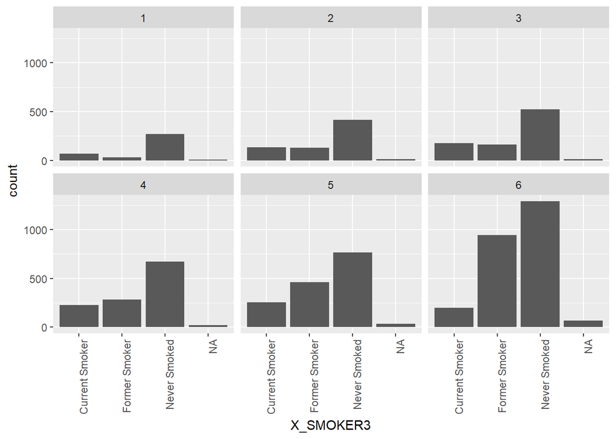

```r
ggplot(data=iowa, aes(x=X_SMOKER3)) + geom_bar()+facet_wrap(~X_AGE_G) + theme(axis.text.x = element_text(angle = 90, hjust = 1))
```

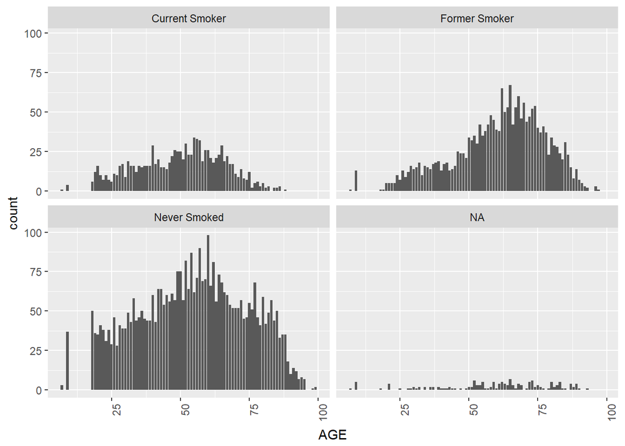

```r
ggplot(data=iowa, aes(x=AGE)) + geom_bar()+facet_wrap(~X_SMOKER3) + theme(axis.text.x = element_text(angle = 90, hjust = 1))
```

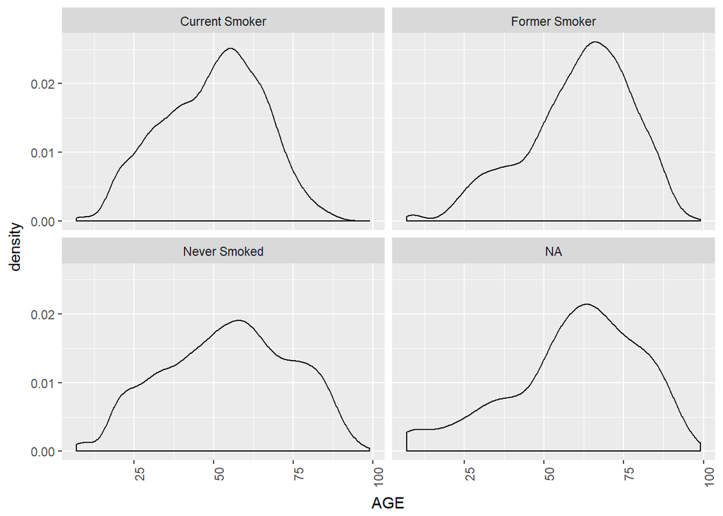

```r
ggplot(data=iowa, aes(x=AGE)) + geom_density()+facet_wrap(~X_SMOKER3) + theme(axis.text.x = element_text(angle = 90, hjust = 1))
```

From the plot we can see that in each age category, te count for “Never smoked is highest”. In age category 1-3 current smokers are more than former smokers but in age category 4-6 former smokers are more than current smokers. This means that many older people quit smoking.

In the plot of AGE vs Smokers we see few values where AGE is less than 10, these may be outliers. After checking the description 7 and 9 were used for missing values.

Other thing to notice is that mean of Former smoker apprers larger than that of Never smoked and current smoker.

5. What percentage of the population has never smoked? Calculate this percentage by age groups (`X_AGE_G`) and gender (`SEX`). Report also on the number of respondents these percentages are based on.

```r
#5
iowa_notNA<-iowa[which(!(iowa$X_SMOKER3=="NA")),]
tot<-dim(iowa_notNA)[1]
iowaNS<-iowa_notNA[which((iowa_notNA$X_SMOKER3=="Never Smoked")),]
#percent nonsmoker
totNS<-dim(iowaNS)[1]
totNS/tot*100
```

```
## [1] 56.17962
```

```r
table(iowaNS$X_AGE_G)/tot*100
```

```
##
##         1         2         3         4         5         6
##  3.834640  5.944405  7.441197  9.607983 10.933713 18.417676
```

```r
table(iowaNS$SEX)/tot*100
```

```
##
##        1        2
## 19.18746 36.99216
```

The non-smoker percentage is based on 7015 number of respondents

Total % never smoked 56.1796151

What is the relationship between age and the number of poor health days? Is this relationship different for men and women? Show plot(s) and describe.

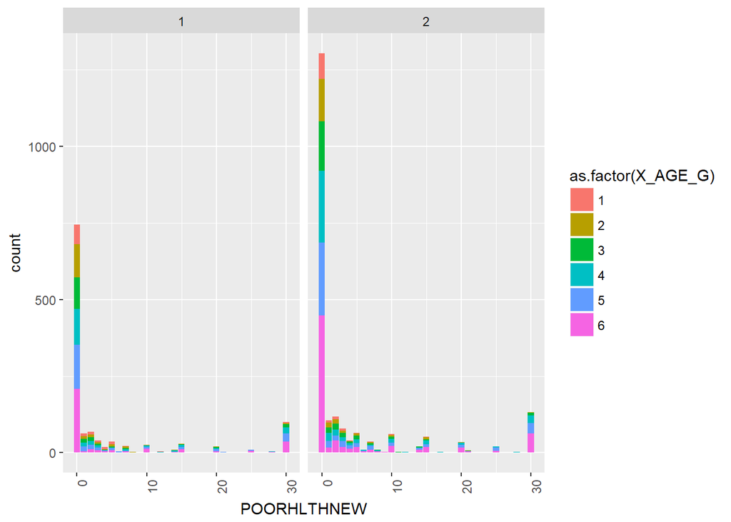

```r
iowa<-iowa %>% mutate(POORHLTHNEW = ifelse(POORHLTH == 88, 0, ifelse(POORHLTH == 77 | POORHLTH == 99, NA, POORHLTH)))
ggplot(data=iowa, aes(x=POORHLTHNEW,fill=as.factor(X_AGE_G))) + geom_bar()+facet_wrap(~SEX, scales = "free_x") + theme(axis.text.x = element_text(angle = 90, hjust = 1))
```

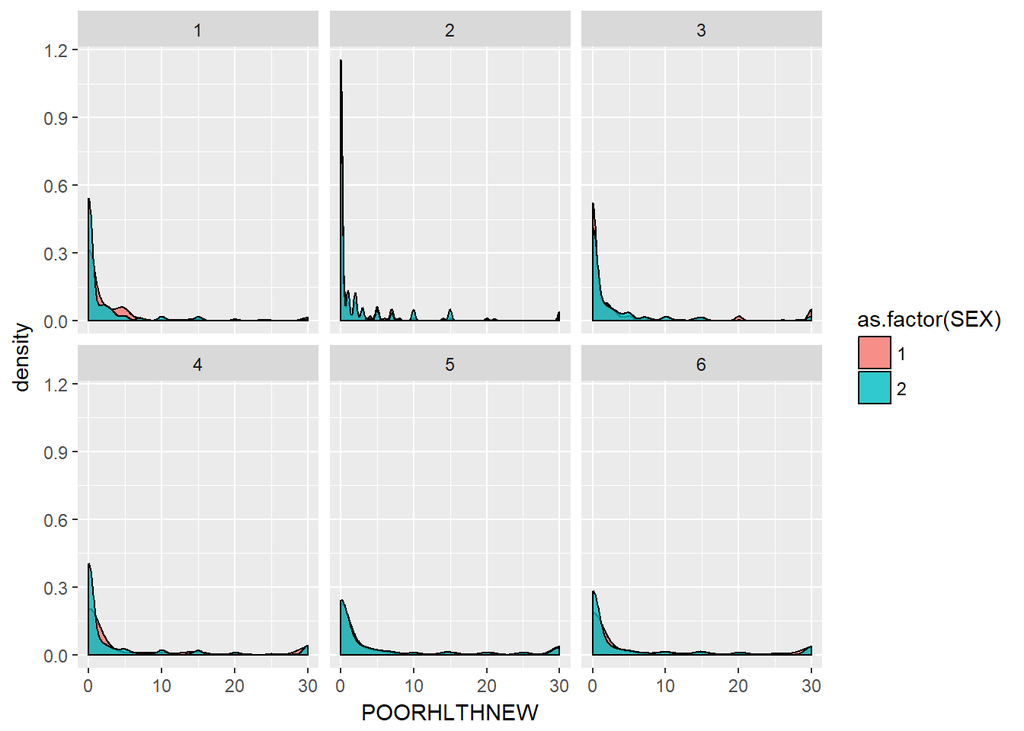

```r
ggplot(data=iowa, aes(x=POORHLTHNEW, fill=as.factor(SEX))) + geom_density(alpha=0.8)+facet_wrap(~X_AGE_G)
```

In the first plot we can see the distribution of AGE by number of days of Poorhealth faceted by sex (1 for male 2 for female). We can see that in females the number of respondents with 0 POORHLTH are higher than those in male. In both Male and Female, the Age 6 has highest frequency where POORHLTH is 30.

In the second plot we can see the distribution of number of respondents faceted by AGE groups and coloured by SEX. For each Age group we dont see much difference in the distribution over POORHLTH.